# Discretização e Codificação

Prof. Cesar Henrique Comin

## Discretização e codificação

- Vimos transformações que **preservam** a informação: mudam a escala ou a distribuição, mas mantêm a ordem e a identidade de cada valor.
- Agora vamos ver transformações que descartam informação (discretização) e que criam novos valores (codificação de categorias).
- As duas operações são espelhos uma da outra:
  - **Discretizar:** número contínuo → categoria ordenada.
  - **Codificar:** categoria → número.

# Discretização

## O que é

- Substituir um valor contínuo pelo **intervalo** ao qual ele pertence.
- Vocabulário: os limites dos intervalos são os **pontos de corte**. A quantidade de intervalos é a **aridade** da discretização.

## Pode acontecer naturalmente em dados reais

```python
print(diabetes["age"].unique())
```

```
<StringArray>
[  '[0-10)',  '[10-20)',  '[20-30)',  '[30-40)',  '[40-50)',  '[50-60)',  '[60-70)',  '[70-80)',
  '[80-90)', '[90-100)']
Length: 10, dtype: str
```

- A idade dos pacientes é expressa em faixas de 10 anos.
- Nesse caso, ela é feita na **coleta**, por exigência de privacidade, de formulário ou de sistema legado.

## Por que discretizar

1. **Não-linearidade:** Um modelo linear só consegue traçar uma reta. Com a coluna dividida em faixas, ele passa a ajustar um valor independente para cada faixa.
2. **Robustez:** Tudo acima de um limiar cai no último intervalo. Naturalmente robusto a outliers.
3. **Interpretabilidade e regulação:** “Faixa etária 60–70” é auditável, “coeficiente 0.0037 por ano de idade” não é. Em crédito e saúde, isso pode ser uma exigência formal.
4. **Ausentes podem virar uma faixa própria**, sem precisar imputar nada.

## Métodos que não precisam de discretização

- Árvores de decisão e *gradient boosting* já fazem isso internamente. Eles escolhem os cortes considerando a variável a ser prevista, e podem escolher cortes diferentes em partes diferentes da árvore.
- O `HistGradientBoosting` do sklearn discretiza cada coluna em até 255 faixas antes de treinar. Por isso o `Hist` do nome.

## `KBinsDiscretizer`

```python
KBinsDiscretizer(n_bins=5, encode="onehot", strategy="quantile")
```

- `n_bins`: número de intervalos desejado.
- `encode`: `"ordinal"` (um número por faixa), `"onehot"` (uma coluna por faixa).
- `strategy`: `"quantile"` ou `"kmeans"`.
- Parâmetro aprendido: `bin_edges_`, os pontos de corte de cada coluna.

## Aplicação das duas estratégias

```python
from sklearn.preprocessing import KBinsDiscretizer

X = diabetes[["num_medications"]]

for strategy in ["quantile", "kmeans"]:
    kb = KBinsDiscretizer(n_bins=5, encode="ordinal", strategy=strategy)
    Xt = kb.fit_transform(X)
    occupancy = histogram(Xt)
    print(strategy)
    print(f"cortes\n{np.round(kb.bin_edges_[0], 1)}")
    print(f"ocupação\n{occupancy}")
```

```
quantile
cortes
[ 1.  9. 12. 15. 20. 62.]
ocupação
[2225 2200 1984 1806 1785]
kmeans
cortes
[ 1.  12.1 19.2 27.2 38.1 62. ]
ocupação
[4366 3409 1540  514  171]
```

## `quantile`: mesma ocupação

- Os cortes são os quantis: cada faixa recebe aproximadamente $n/k$ observações.
- É o padrão do sklearn e a escolha usual na prática.
- Vantagem direta: toda faixa tem massa suficiente para uma estimativa estável.
- Desvantagem: os cortes não têm significado no domínio.

## `kmeans`: agrupar por proximidade

- Aplica um k-means unidimensional sobre os valores e usa as fronteiras entre os grupos como cortes.
- Útil quando há grupos de tamanhos diferentes nos dados.

```python
rng = np.random.default_rng(3)
consumption = np.concatenate([rng.normal(20, 3, 800),   # 800 clientes residenciais
                              rng.normal(60, 4, 200)])  # 200 clientes comerciais
C = consumption.reshape(-1, 1)

for strategy in ["quantile", "kmeans"]:
    kb = KBinsDiscretizer(n_bins=2, encode="ordinal", strategy=strategy).fit(C)
```

## `kmeans`: agrupar por proximidade

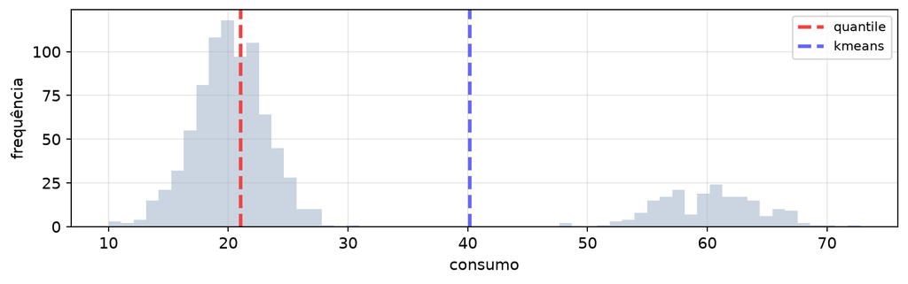

- `quantile` corta em 21: **dentro do pico principal**, separando clientes idênticos e juntando os 200 comerciais com metade dos residenciais.

## `pd.cut` e `pd.qcut`

- Os equivalentes do pandas, com uma vantagem para análise exploratória: rótulos legíveis.

```python
bins = pd.qcut(diabetes["num_medications"], q=4)
print(bins.value_counts().sort_index())
```

```
num_medications
(0.999, 9.0]    2550
(9.0, 14.0]     3025
(14.0, 19.0]    2200
(19.0, 62.0]    2225
Name: count, dtype: int64
```

- `pd.cut` recebe os cortes explicitamente (útil quando o domínio já define as faixas). `pd.qcut` usa quantis.

## Um exemplo: consumo de energia

- Um prédio gasta energia com **aquecimento** quando faz frio e com **ar-condicionado** quando faz calor. Queremos prever o consumo diário a partir da temperatura externa.

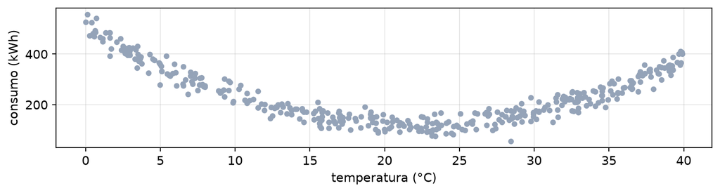

## Um exemplo: consumo de energia

- Um modelo linear define **uma reta**: `consumo = a + b × temperatura`. Ajustá-lo é procurar os dois números `a` e `b` que deixam a reta o mais perto possível dos pontos.
- Com uma única coluna de entrada, é só isso que ele pode fazer: Uma reta para modelar os dados.

```python
from sklearn.linear_model import LinearRegression
from sklearn.metrics import mean_absolute_error

line_model = LinearRegression().fit(temperature, consumption)
```

## Um exemplo: consumo de energia

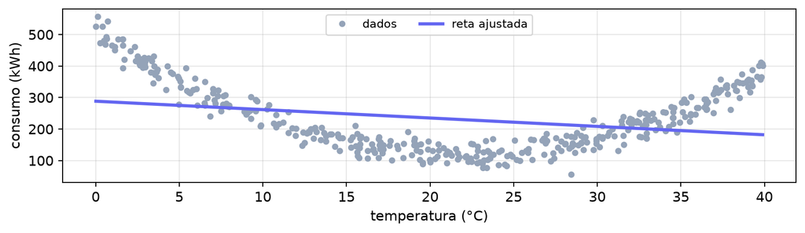

- A reta erra em quase todo lugar.
- A inclinação é **negativa**. O modelo afirma que “quanto mais quente, menos energia”.

## O que a discretização muda na tabela

```python
kb = KBinsDiscretizer(n_bins=8, encode="onehot-dense", strategy="uniform")
cat_temp = kb.fit_transform(temperature)

temperature_edges = np.round(kb.bin_edges_[0]).astype(int)
labels = [f"{a}-{b}" for a, b in zip(temperature_edges[:-1], temperature_edges[1:])]

print("Original:")
print(temperature[:3])
print("Discretizada:")
print(pd.DataFrame(cat_temp[:3].astype(int), columns=labels))
```

```
Original:
[[25.47846749]
 [10.79146855]
 [ 1.63894096]]
Discretizada:
   0-5  5-10  10-15  15-20  20-25  25-30  30-35  35-40
0    0     0      0      0      0      1      0      0
1    0     0      1      0      0      0      0      0
2    1     0      0      0      0      0      0      0
```

## O resultado: uma escada

```python
step_model = LinearRegression().fit(cat_temp, consumption)
```

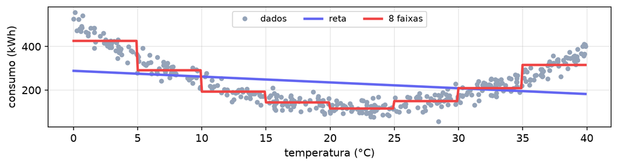

- A representação discretizada permite ao modelo linear ajustar um valor para cada faixa, em vez de uma inclinação só.

## Vantagens do modelo linear sobre dados discretizados

- **Interpretação:** “De 0 a 5 °C o prédio gasta 426 kWh por dia” é uma frase que pode ser entendida, conferida e contestada. “O consumo varia 2.7 kWh por °C” é menos interpretável.
- **Não é preciso conhecer a forma da curva**.

# Weight of Evidence

## Weight of Evidence

- *Credit scoring* é uma indústria **regulada**: o modelo que nega crédito precisa ser explicado ao cliente, ao auditor e ao regulador.
- O formato aceito há décadas é o **scorecard**: uma tabela de faixas, cada uma valendo um número de pontos, que se somam.
- Isso exige que o modelo final seja uma **regressão logística** sobre variáveis discretizadas.
- O **Weight of Evidence** é a codificação que faz essa combinação funcionar.

## A definição

Para cada faixa, compare a proporção de **maus** pagadores naquela faixa com a proporção de **bons**:

$$\text{WoE}_i = \ln\!\left(\frac{\text{maus}_i / \text{maus}_{\text{total}}}{\text{bons}_i / \text{bons}_{\text{total}}}\right)$$

- WoE > 0: a faixa concentra mais maus do que a média. WoE < 0: concentra mais bons.
- WoE = 0: a faixa se comporta como a população inteira.

## Implementação

```python
def woe(bins, y, s=0.5):
    """Tabela de WoE por faixa. y = 1 indica o evento adverso."""
    group = y.groupby(bins)
    bad, n = group.sum(), group.size()
    good = n - bad
    k = len(group)
    p_bad = (bad + s) / (bad.sum() + s*k)      # s suaviza as faixas vazias
    p_good = (good + s) / (good.sum() + s*k)
    woe_values = np.log(p_bad / p_good)
    return pd.DataFrame({"n": n, "taxa": (bad / n).round(3), "woe": woe_values.round(3)})
```

- `s` suaviza as faixas vazias e evita divisão por zero.

## A tabela

```python
y = (diabetes["readmitted"] == "<30").astype(int)   # readmissão em menos de 30 dias

table = woe(diabetes["age"], y)
print(table.to_string())
```

```
             n   taxa    woe
age
[0-10)      69  0.014 -1.733
[10-20)    178  0.067 -0.500
[20-30)    163  0.098 -0.102
[30-40)    447  0.107 -0.020
[40-50)   1081  0.117  0.076
[50-60)   1846  0.095 -0.159
[60-70)   2165  0.109 -0.015
[70-80)   2649  0.119  0.087
[80-90)   1228  0.123  0.127
[90-100)   174  0.098 -0.108
```

## Lendo a tabela

- A faixa `[0-10)` tem WoE **-1.73**: crianças quase nunca são readmitidas em 30 dias (1.4% contra 11% da população).
- Faixas com WoE próximo de zero não distinguem nada e são candidatas a serem **agrupadas** com as vizinhas.
- No exemplo usamos a idade, mas podemos utilizar N variáveis preditoras. O WoE coloca todas **na mesma escala**, e a regressão logística final combina os WoEs de cada faixa em um score total.

## Problemas com discretização

1. **Resolução perdida dentro da faixa:** Dois clientes com renda de R$ 3.000 e R$ 9.999 viram o mesmo cliente se a faixa for [3000, 10000].
2. **Descontinuidade artificial na fronteira:** R$ 2.999 e R$ 3.000 são praticamente idênticos, mas passam a receber tratamentos completamente diferentes.
3. **Instabilidade:** Os cortes são estimados a partir da amostra. Outra amostra da mesma população produz cortes diferentes, e o modelo pode mudar.

## A regra

- Discretizar quando o motivo for **humano**: leitura, relatório, regulação, um scorecard que alguém precisa auditar.
- Discretizar quando o motivo for **robustez explícita**: um limiar acima do qual você deliberadamente não quer distinguir nada.

# Codificação de variáveis categóricas

## O problema

- Modelos recebem números. Uma coluna de texto precisa virar uma ou mais colunas numéricas:

```python
categorical = diabetes.select_dtypes("str")
print(categorical[["diag_1", "medical_specialty", "age", "race", "gender"]]
      .nunique())
```

```
diag_1               446
medical_specialty     43
age                   10
race                   5
gender                 2
dtype: int64
```

- `diag_1` (código de diagnóstico): centenas de categorias, **alta cardinalidade**.
- `medical_specialty`: dezenas, a maioria rara.
- `age`: 10 categorias com uma **ordem** natural.
- `race` e `gender`: poucas categorias, **sem ordem**.

## `OrdinalEncoder`

- Um inteiro por categoria.

```python
from sklearn.preprocessing import OrdinalEncoder

education = pd.DataFrame({"nivel": ["superior", "fundamental", "medio", "fundamental"]})
order = [["fundamental", "medio", "superior"]]

oe = OrdinalEncoder(categories=order).set_output(transform="pandas")
print(pd.concat([education, oe.fit_transform(education)], axis=1)
        .to_string(header=["categoria", "código"]))
```

```
     categoria código
0     superior    2.0
1  fundamental    0.0
2        medio    1.0
3  fundamental    0.0
```

## Cuidado com o OrdinalEncoder!

```python
cities = pd.DataFrame({"cidade": ["SP", "RJ", "BH"]})
codes = OrdinalEncoder().fit_transform(cities).ravel()
print(dict(zip(cities["cidade"], codes)))
```

```
{'SP': np.float64(2.0), 'RJ': np.float64(1.0), 'BH': np.float64(0.0)}
```

- Essa codificação implica que:
  - BH < RJ < SP
  - A diferença entre BH e SP é o dobro da diferença entre BH e RJ
  - RJ está “entre” os outros dois estados.

## `OneHotEncoder`

- Uma coluna binária por categoria. Nenhuma ordem é sugerida, e é o padrão para variáveis nominais.

```python
from sklearn.preprocessing import OneHotEncoder

oh = OneHotEncoder(sparse_output=False).set_output(transform="pandas")
print(oh.fit_transform(cities))
```

```
   cidade_BH  cidade_RJ  cidade_SP
0        0.0        0.0        1.0
1        0.0        1.0        0.0
2        1.0        0.0        0.0
```

- `sparse_output=True` é o padrão e devolve uma matriz esparsa, isto é, otimizada para armazenar muitos zeros.

## O parâmetro `drop`

- As colunas geradas somam sempre 1, então qualquer uma delas é redundante.
- Em regressão linear sem regularização, isso deixa os coeficientes indeterminados. A solução é `drop="first"`, que remove a primeira coluna.
- Em modelos regularizados e em árvores, não há problema em manter todas as colunas.

## Alta cardinalidade

- O `OneHotEncoder` explode em colunas quando a variável tem muitas categorias:

```python
specialty = diabetes[["medical_specialty"]].fillna("(ausente)")
oh = OneHotEncoder(sparse_output=False).fit(specialty)
print(f"{len(oh.get_feature_names_out())} colunas")
```

```
44 colunas
```

## Alta cardinalidade

```python
specialty = diabetes[["medical_specialty"]].fillna("(ausente)")

for kwargs in [{"min_frequency": 0.01}, {"max_categories": 6}]:
    oh = OneHotEncoder(sparse_output=False, **kwargs).fit(specialty)
    print(f"{str(kwargs)} -> {len(oh.get_feature_names_out())} colunas")
```

```
{'min_frequency': 0.01} -> 14 colunas
{'max_categories': 6} -> 6 colunas
```

- `min_frequency`: categorias com frequência menor que o limiar vão para uma categoria única chamada `infrequent_sklearn`.
- `max_categories`: mantém apenas as `max_categories` mais frequentes, e o resto vai para `infrequent_sklearn`.

## Considerações sobre métodos baseados em árvores

- O scikit-learn possui a classe `HistGradientBoostingClassifier`, que é uma implementação básica de um tipo de método chamado de *gradient boosting* baseados em árvores.
- Bibliotecas com implementações mais avançadas e otimizadas de *gradient boosting* são: `LightGBM`, `XGBoost` e `CatBoost`.
- Esse tipo de modelo é capaz de lidar com a maioria dos problemas que vimos e que vamos ver de forma automática, sem precisar de pré-processamento manual.

## Considerações sobre métodos baseados em árvores

- **Valores ausentes:** Lidam de forma nativa. Valores ausentes são colocados em ramos que maximizam a função de perda.
- **Escalas distintas:** Lidam de forma nativa. Decisões na árvore dependem apenas da ordem dos valores.
- **Caudas longas / assimetria:**
  - Lidam de forma nativa nas variáveis de entrada (X).
  - Lidam de forma quase-nativa nas variáveis de saída (y): Basta usar funções de perda robustas. Pode ser preciso aplicar transformação de potência / log.

## Considerações sobre métodos baseados em árvores

- **Variáveis categóricas:**
  - Lidam nativamente com variáveis categóricas ordinais.
  - Lidam nativamente com variáveis categóricas nominais, mas cada biblioteca utiliza um procedimento distinto para lidar com elas. Por exemplo, CatBoost possui menos propensão a sobreajuste quando o número de categorias é muito alto.

## Considerações sobre métodos baseados em árvores

- **Outliers:**
  - Lidam de forma nativa nas variáveis de entrada (X).
  - Lidam de forma quase-nativa nas variáveis de saída (y): Basta usar funções de perda robustas. Pode ser preciso identificar e tratar os outliers.
- **Classes desbalanceadas:** Lidam de forma nativa usando funções de perda ponderadas.

## Considerações sobre métodos baseados em árvores

- **Redução no número de variáveis:** Lidam de forma nativa, pois árvores ignoram variáveis irrelevantes. Pode ser útil se a quantidade de variáveis irrelevantes for muito grande.
- **Engenharia de atributos:** Muito importante mesmo em algoritmos de árvore.